# Ambulatory or residential? a multi-state analysis of treatments for substance use disorders (Step 3)

15 septiembre, 2021

# Cumulative Transition Hazards of Joint Models

## Parametric

Cumulative baseline hazard can be estimated non-parametrically through a Breslow estimator. Must take note that we are assuming a semi-markov process in these transitions. The cumulative hazards obtained through the times specified by 183 points. We added the setting at baseline as the first covariate, with the outcome of each treatment as (treatment completion, in 0/1 format) users pass through each transition. Equally, we included the time of arrival as a covariate to each transition (excluding the admission states, because there is no time of arrival).

```r
# Semi-parametric models
#Since there are tied event times, we need to specify ties="breslow" in order to obtain the Aalen-Johansen estimator of
#the transition probability

formula3<-
as.formula(paste0("Surv(time, status) ~", paste0(fitform2," + arrival + strata(trans)")[[3]]))


#_time tipo_de_plan_res_1 TD_1 TD_2 TD_3 TD_4 _start#

formula3_mstate<-
as.formula(paste0("Surv(time, status) ~", paste0(fitform2," + factor(TD_1)+ factor(TD_2)+ factor(TD_3)+ factor(TD_4)+ arrival + strata(trans)")[[3]]))


formula3_mstate_stratified<-
as.formula(paste0("Surv(time, status) ~", paste0(fitform2," + factor(TD_1)+ factor(TD_2)+ factor(TD_3)+ factor(TD_4)+ arrival")[[3]]))

formula3_mstate_stratified_arr<-
as.formula(paste0("Surv(time, status) ~", paste0(fitform2," + factor(TD_1)+ factor(TD_2)+ factor(TD_3)+ factor(TD_4)+ arrival")[[3]]))


#2021-06-03, I changed the regression to Surv(Tstart, Tstop, status) format, but with arrival time.

paste0("For the first transition, we introduced the following Formula: ")
```

```
## [1] "For the first transition, we introduced the following Formula: "
```

```r
formula3_mstate_stratified
```

```
## Surv(time, status) ~ factor(tipo_de_plan_res_1) + factor(TD_1) +
##     factor(TD_2) + factor(TD_3) + factor(TD_4) + arrival
```

```r
paste0("For the second and further transition, we introduced the following Formula: ")
```

```
## [1] "For the second and further transition, we introduced the following Formula: "
```

```r
formula3_mstate_stratified_arr
```

```
## Surv(time, status) ~ factor(tipo_de_plan_res_1) + factor(TD_1) +
##     factor(TD_2) + factor(TD_3) + factor(TD_4) + arrival
```

As seen in the formula above, we included the transition-specific covariables regarding the time that arrived to the state into the models.

```r
fits_c_wei2 <- vector(mode = "list", length = n_trans2)
fits_c_weiph2 <- vector(mode = "list", length = n_trans2)
fits_c_llogis2 <- vector(mode = "list", length = n_trans2)
fits_c_gomp2 <- vector(mode = "list", length = n_trans2)
fits_c_logn2 <- vector(mode = "list", length = n_trans2)
fits_c_exp2 <- vector(mode = "list", length = n_trans2)
fits_c_gam2 <- vector(mode = "list", length = n_trans2)
fits_c_ggam2 <- vector(mode = "list", length = n_trans2)
fits_c_genf2 <- vector(mode = "list", length = n_trans2)
fits_c_genf_orig2 <- vector(mode = "list", length = n_trans2)
fits_c_ggam_orig2 <- vector(mode = "list", length = n_trans2)
fits_c_rp022 <- vector(mode = "list", length = n_trans2)
fits_c_rp032 <- vector(mode = "list", length = n_trans2)
fits_c_rp042 <- vector(mode = "list", length = n_trans2)
fits_c_rp052 <- vector(mode = "list", length = n_trans2)
fits_c_rp062 <- vector(mode = "list", length = n_trans2)
fits_c_rp072 <- vector(mode = "list", length = n_trans2)
fits_c_rp082 <- vector(mode = "list", length = n_trans2)
fits_c_rp092 <- vector(mode = "list", length = n_trans2)
fits_c_rp102 <- vector(mode = "list", length = n_trans2)

dists_w_covs_4s_w_arrival<-cbind.data.frame(covs=c(rep("fits_c_",(20)*n_trans2)),
              formal=rep(c("Weibull (AFT)", "Weibull (PH)", "Gompertz", "Log-logistic", "Gamma",
                "Generalized gamma", "Generalized gamma (original)", "Lognormal", "Exponential", "Generalized F", "Generalized F(original)", paste0("RP0",2:9),"RP10"),1*n_trans2),
              dist=c("weibull", "weibullph", "llogis", "gamma", "gengamma","gengamma.orig", "gompertz", "lnorm", "exp", "genf","genf.orig",rep("no dist",9)),
              model=rep(c("wei2", "weiph2", "gomp2", "llogis2", "gam2","ggam2", "ggam_orig2", "logn2", "exp2", "genf2","genf_orig2", paste0("rp0",2:9,2),"rp102"),1*n_trans2),
              trans=rep(1:n_trans2, each=20))

ms_d_match_surv$arrival<-ms_d_match_surv$Tstart
ms_d_match_surv_exp<-mstate::expand.covs(ms_d_match_surv, "TD", append = TRUE, longnames =F)
#ms_d_match_surv_exp$TD<-ms_d_match_surv_res$TD

ms_d_match_surv_res2<-
  #El arrival y el número al lado del arrival repreenta el número de la transición
  mstate::expand.covs(ms_d_match_surv, "TD", append = TRUE, longnames =F)

if(no_mostrar==1){
  ms_d_match_surv %>%
  data.frame() %>%
  dplyr::mutate(tipo_de_plan_res=dplyr::case_when(tipo_de_plan_res_1==1 & trans==1~1,
                                                  tipo_de_plan_res_2==1 & trans==2~1,
                                                  tipo_de_plan_res_3==1 & trans==3~1,
                                                  tipo_de_plan_res_4==1 & trans==4~1,
                                                  T~0)) %>%
    dplyr::mutate(TD=dplyr::case_when(TD_1==1 & trans==1~1,
                                      TD_2==1 & trans==2~1,
                                      TD_3==1 & trans==3~1,
                                      TD_4==1 & trans==4~1,
                                      T~0))
}

#ms_d_match_surv_exp <- expand.covs(ms_d_match_surv_exp, "TD", append = TRUE, longnames =F)

#ms_d_match_surv_exp[is.na(ms_d_match_surv_exp$TD_2),"TD_2"]<-0
#ms_d_match_surv_exp[is.na(ms_d_match_surv_exp$TD_3),"TD_3"]<-0
#ms_d_match_surv_exp[is.na(ms_d_match_surv_exp$TD_4),"TD_4"]<-0

  #mstate::expand.covs(ms_d_match_surv, "arrival", append = TRUE, longnames = FALSE)

#_#_#_#_#_#_#_#_#_#_#_#_#_#_#_#_#_#_#_#_#_#_#_#_#_#_#_#_#_#_#_#_#_#_#_#_#_#_#_#_#_#_
#_#_#_#_#_#_#_#_#_#_#_#_#_#_#_#_#_#_#_#_#_#_#_#_#_#_#_#_#_#_#_#_#_#_#_#_#_#_#_#_#_#_
no_attempts <- 30

fits_cox2<-list()
fits_c_cox2<-list()

form<-
  function(i=1){
  f<-dplyr::case_when(i==4~paste0("Surv(time, status) ~ ",fitform2," + factor(TD_1)+ factor(TD_2)+ factor(TD_3)+ factor(TD_4)+ arrival")[[3]],i==3~paste0("Surv(time, status) ~ ",fitform2," + factor(TD_1)+ factor(TD_2)+ factor(TD_3)+ arrival")[[3]],i==2~paste0("Surv(time, status) ~ ",fitform2," + factor(TD_1)+ factor(TD_2)+ arrival")[[3]],T~paste0("Surv(time, status) ~ ",fitform2," + factor(TD_1)")[[3]])
  return(f)
}

for (i in 1:n_trans2){
  r <- NULL
  attempt <- 0
  while( is.null(r) && attempt <= no_attempts ) {
    attempt <- attempt + 1
    try(
      r <- flexsurvreg(formula=as.formula(form(i)),
                                 data = subset(ms_d_match_surv_exp, trans == i),
                                 dist = "weibull")
    )
  }
  fits_c_wei2[[i]] <- r
}

for (i in 3:n_trans2){
  r <- NULL
  attempt <- 0
  while( is.null(r) && attempt <= no_attempts ) {
    attempt <- attempt + 1
    try(
      r <- flexsurvreg(formula=as.formula(form(i)),
                                 data = subset(ms_d_match_surv_exp, trans == i),
                                 dist = "weibullph")
    )
  }
  fits_c_weiph2[[i]] <- r
}
```

[output not shown]

[output cut: 69 more lines]

[output not shown]

```r
for (i in 1:n_trans2){
  r <- NULL
  attempt <- 0
  while( is.null(r) && attempt <= no_attempts ) {
    attempt <- attempt + 1
    try(
      r <- flexsurvreg(formula=as.formula(form(i)),
                                 data = subset(ms_d_match_surv_exp, trans == i),
                                 dist = "llogis")
    )
  }
  fits_c_llogis2[[i]] <- r
}

for (i in 1:n_trans2){
  r <- NULL
  attempt <- 0
  while( is.null(r) && attempt <= no_attempts ) {
    attempt <- attempt + 1
    try(
      r <- flexsurvreg(formula=as.formula(form(i)),
                                 data = subset(ms_d_match_surv_exp, trans == i),
                                 dist = "gamma")
    )
  }
  fits_c_gam2[[i]] <- r
}
```

[output not shown]

[output cut: 69 more lines]

[output not shown]

```r
for (i in 1:n_trans2){
    r <- NULL
    attempt <- 0
    while( is.null(r) && attempt <= no_attempts ) {
      attempt <- attempt + 1
    try(
      r <- flexsurvreg(formula=as.formula(form(i)),
                                   data = subset(ms_d_match_surv_exp, trans == i),
                                   dist = "gengamma")
      )
    }
    fits_c_ggam2[[i]] <- r
}
for (i in 1:n_trans2){
    r <- NULL
    attempt <- 0
    while( is.null(r) && attempt <= no_attempts ) {
      attempt <- attempt + 1
    try(
      r <- flexsurvreg(formula=as.formula(form(i)),
                                   data = subset(ms_d_match_surv_exp, trans == i),
                                   dist = "gompertz")
      )
    }
    fits_c_gomp[[i]] <- r
}
```

[output not shown]

```r
for (i in 1:n_trans2){
    r <- NULL
    attempt <- 0
    while( is.null(r) && attempt <= no_attempts ) {
      attempt <- attempt + 1
    try(
      r <- flexsurvreg(formula=as.formula(form(i)),
                                   data = subset(ms_d_match_surv_exp, trans == i),
                                   dist = "lnorm")
      )
    }
    fits_c_logn2[[i]] <- r
}

for (i in 1:n_trans2){
    r <- NULL
    attempt <- 0
    while( is.null(r) && attempt <= no_attempts ) {
      attempt <- attempt + 1
    try(
      r <- flexsurvreg(formula=as.formula(form(i)),
                                   data = subset(ms_d_match_surv_exp, trans == i),
                                   dist = "exp")
      )
    }
    fits_c_exp2[[i]] <- r
}


for (i in 1:n_trans2){
    r <- NULL
    attempt <- 0
    while( is.null(r) && attempt <= no_attempts ) {
      attempt <- attempt + 1
    try(
      r <- flexsurvreg(formula=as.formula(form(i)),
                                   data = subset(ms_d_match_surv_exp, trans == i),
                                   dist = "genf")
      )
    }
    fits_c_genf2[[i]] <- r
}
for (i in 1:n_trans2){
    r <- NULL
    attempt <- 0
    while( is.null(r) && attempt <= no_attempts ) {
        attempt <- attempt + 1
    try(
      r <- flexsurvreg(formula=as.formula(form(i)),
                             data = subset(ms_d_match_surv_exp, trans == i),
                             dist = "gengamma.orig")
        )
    }
    fits_c_ggam_orig2[[i]] <- r
}
for (i in 1:n_trans2){
    r <- NULL
    attempt <- 0
    while( is.null(r) && attempt <= no_attempts ) {
        attempt <- attempt + 1
    try(
      r <- flexsurvreg(formula=as.formula(form(i)),
                             data = subset(ms_d_match_surv_exp, trans == i),
                             dist = "genf.orig")
        )
    }
    fits_c_genf_orig2[[i]] <- r
}
for (i in 1:n_trans2){
    r <- NULL
    attempt <- 0
    while( is.null(r) && attempt <= no_attempts ) {
      attempt <- attempt + 1
    try(
      r <- flexsurvspline(formula=as.formula(form(i)),
                            k=1,
                               data = subset(ms_d_match_surv_exp, trans == i))
      )
    }
    fits_c_rp022[[i]] <- r
}

for (i in 1:n_trans2){
    r <- NULL
    attempt <- 0
    while( is.null(r) && attempt <= no_attempts ) {
      attempt <- attempt + 1
    try(
      r <- flexsurvspline(formula=as.formula(form(i)),
                            k=2,
                               data = subset(ms_d_match_surv_exp, trans == i))
      )
    }
    fits_c_rp032[[i]] <- r
}

for (i in 1:n_trans2){
    r <- NULL
    attempt <- 0
    while( is.null(r) && attempt <= no_attempts ) {
      attempt <- attempt + 1
    try(
      r <- flexsurvspline(formula=as.formula(form(i)),
                            k=3,
                               data = subset(ms_d_match_surv_exp, trans == i))
      )
    }
    fits_c_rp042[[i]] <- r
}

for (i in 1:n_trans2){
    r <- NULL
    attempt <- 0
    while( is.null(r) && attempt <= no_attempts ) {
      attempt <- attempt + 1
    try(
      r <- flexsurvspline(formula=as.formula(form(i)),
                            k=4,
                               data = subset(ms_d_match_surv_exp, trans == i))
      )
    }
    fits_c_rp052[[i]] <- r
}
for (i in 1:n_trans2){
    r <- NULL
    attempt <- 0
    while( is.null(r) && attempt <= no_attempts ) {
      attempt <- attempt + 1
    try(
      r <- flexsurvspline(formula=as.formula(form(i)),
                            k=5,
                               data = subset(ms_d_match_surv_exp, trans == i))
      )
    }
    fits_c_rp062[[i]] <- r
}

for (i in 1:n_trans2){
    r <- NULL
    attempt <- 0
    while( is.null(r) && attempt <= no_attempts ) {
      attempt <- attempt + 1
    try(
      r <- flexsurvspline(formula=as.formula(form(i)),
                            k=6,
                               data = subset(ms_d_match_surv_exp, trans == i))
      )
    }
    fits_c_rp072[[i]] <- r
}

for (i in 1:n_trans2){
    r <- NULL
    attempt <- 0
    while( is.null(r) && attempt <= no_attempts ) {
      attempt <- attempt + 1
    try(
      r <- flexsurvspline(formula=as.formula(form(i)),
                            k=7,
                               data = subset(ms_d_match_surv_exp, trans == i))
      )
    }
    fits_c_rp082[[i]] <- r
}

for (i in 1:n_trans2){
    r <- NULL
    attempt <- 0
    while( is.null(r) && attempt <= no_attempts ) {
      attempt <- attempt + 1
    try(
      r <- flexsurvspline(formula=as.formula(form(i)),
                            k=8,
                               data = subset(ms_d_match_surv_exp, trans == i))
      )
    }
    fits_c_rp092[[i]] <- r
}

for (i in 1:n_trans2){
    r <- NULL
    attempt <- 0
    while( is.null(r) && attempt <= no_attempts ) {
      attempt <- attempt + 1
    try(
      r <- flexsurvspline(formula=as.formula(form(i)),
                            k=9,
                               data = subset(ms_d_match_surv_exp, trans == i))
      )
    }
    fits_c_rp102[[i]] <- r
}

#_#_#_#_#_#_#_#_#_#_#_#_#_#_#_#_#_#_#_#_#_#_#_#_#_#_#_#_#_#_#_#_#_#_#_#_#_#_#_#_#_#_
#_#_#_#_#_#_#_#_#_#_#_#_#_#_#_#_#_#_#_#_#_#_#_#_#_#_#_#_#_#_#_#_#_#_#_#_#_#_#_#_#_#_
```

```r
  #formula3_mstate_stratified
  #ms_d_match_surv_exp2
```

```
#> ### First fix a patient with reference values for the covariates
#> ### and 0 for all the time-dependent covariates; this will give the
#> ### baseline hazards
```

```r
#_#_#_#_#_#_#_#_#_#_#_#_#_#_#_#_#_#_#_#_#_#_#_#_#_#_#_#_#_#_#_#_#_#_#_#_#_#_
# Database to contrast adjustments
newdat_a <- data.table::data.table(tipo_de_plan_res_1= factor(c(rep(1,1*n_trans2))),
  #comp_status= factor(rep(c("Therapeutic discharge","Discharge without clinical advice"),2)),
  TD_1=rep(0,),
  TD_2=rep(0,),
  TD_3=rep(0,),
  TD_4=rep(0,),
  arrival=rep(0,),
  strata= rep(1:n_trans2,1)
                       )
newdat_b <- data.table::data.table(tipo_de_plan_res_1= factor(c(rep(0,1*n_trans2))),
  #comp_status= factor(rep(c("Therapeutic discharge","Discharge without clinical advice"),2)),
  TD_1=rep(0,),
  TD_2=rep(0,),
  TD_3=rep(0,),
  TD_4=rep(0,),
  arrival=rep(0,),
  strata= rep(1:n_trans2,1)
                       )
newdat_a_1096 <- data.table::data.table(tipo_de_plan_res_1= factor(c(rep(1,1*n_trans2))),
  #comp_status= factor(rep(c("Therapeutic discharge","Discharge without clinical advice"),2)),
    TD_1=rep(0,),
  TD_2=rep(0,),
  TD_3=rep(0,),
  TD_4=rep(0,),
  arrival=rep(round((365.25*3),0),),
  strata= rep(1:n_trans2,1)
                       )
newdat_b_1096 <- data.table::data.table(tipo_de_plan_res_1= factor(c(rep(0,1*n_trans2))),
  #comp_status= factor(rep(c("Therapeutic discharge","Discharge without clinical advice"),2)),
    TD_1=rep(0,),
  TD_2=rep(0,),
  TD_3=rep(0,),
  TD_4=rep(0,),
  arrival=rep(round((365.25*3),0),),
  strata= rep(1:n_trans2,1)
                       )

#_#_#_#_#_#_#_#_#_#_#_#_#_#_#_#_#_#_#_#_#_#_#_#_#_#_#_#_#_#_#_#_#_#_#_#_#_#_#_#_#_#_
#_#_#_#_#_#_#_#_#_#_#_#_#_#_#_#_#_#_#_#_#_#_#_#_#_#_#_#_#_#_#_#_#_#_#_#_#_#_#_#_#_#_

fitted_flexsurvreg2<-data.frame()
fit_flexsurvreg2<-data.frame()

for (i in 1:nrow(dists_w_covs_4s_w_arrival)){  #

cat(paste0("#### Flexible Survival Model (w/ covs): ",
             dists_w_covs_4s_w_arrival[i,"formal"], "; transition: ",dists_w_covs_4s_w_arrival[i,"trans"], "\n \n"))

model<-paste0("fits_c_",dists_w_covs_4s_w_arrival[i,"model"])
      #_#_#_#_#_#_
      #se queda pegado en la fila 62, modelo: fits_c_weiph2
      #_#_#_#_#_#_

invisible(c("Test"))
#   fitted_flexsurvreg2_prueba_out<-  data.table::data.table(summary(fits_c_wei2[[2]], newdata= newdat_a, newtime=unique(fitted_km$time), type = "survival", tidy=T))
#    fitted_flexsurvreg2_prueba_res<- data.table::data.table(summary(fits_c_wei2[[2]], newdata= newdat_b, newtime=unique(fitted_km$time), type = "survival", tidy=T))
   #t=newtime0,

    # Generate fit indices
 #   fit_flexsurvreg2_prueba<-cbind(dist= "wei",
#             transition=2,
#             fitstats.flexsurvreg(fits_c_wei2[[2]]))

invisible(c("Real"))
tryCatch(
  if(!is.null(get(model)[[dists_w_covs_4s_w_arrival[i,"trans"]]])){
  #Generate databases
   fitted_flexsurvreg2<- dplyr::bind_rows(fitted_flexsurvreg2,cbind.data.frame(dist=rep(dists_w_covs_4s_w_arrival[i,"formal"],),
                              trans=rep(dists_w_covs_4s_w_arrival[i,"trans"],),
                              residential=rep(1,),
                              data.table::data.table(summary(get(model)[[dists_w_covs_4s_w_arrival[i,"trans"]]], newdata= newdat_a, newtime=unique(fitted_km$time), type = "survival", tidy=T))))
    fitted_flexsurvreg2<- dplyr::bind_rows(fitted_flexsurvreg2,cbind.data.frame(dist=rep(dists_w_covs_4s_w_arrival[i,"formal"],),
                              trans=rep(dists_w_covs_4s_w_arrival[i,"trans"],),
                              residential=rep(0,),
                              data.table::data.table(summary(get(model)[[dists_w_covs_4s_w_arrival[i,"trans"]]], newdata= newdat_b,  newtime=unique(fitted_km$time), type = "survival", tidy=T))))
   #t=newtime0,
    # Generate fit indices
    fit_flexsurvreg2<-rbind(fit_flexsurvreg2,
       cbind(dist= dists_w_covs_4s_w_arrival[i,"formal"],
             transition=dists_w_covs_4s_w_arrival[i,"trans"],
             fitstats.flexsurvreg(get(model)[[dists_w_covs_4s_w_arrival[i,"trans"]]])))
    #the BIC may not be appropriate if none of the candidate models are considered to be close to the ‘true’ model.
    } else {
    cat(paste0("The model that assumed a ",dists_w_covs_4s_w_arrival[i,"formal"]," distribution for the transition number ",dists_w_covs_4s_w_arrival[i,"trans"]," did not converge \n\n"))
    }, error=function(e) {
      cat(paste0("The model that assumed a ",dists_w_covs_4s_w_arrival[i,"formal"]," distribution for the transition number ",dists_w_covs_4s_w_arrival[i,"trans"]," did not converge (empty) \n\n"))
  })
}
```

```
## #### Flexible Survival Model (w/ covs): Weibull (AFT); transition: 1
##
## #### Flexible Survival Model (w/ covs): Weibull (PH); transition: 1
##
## The model that assumed a Weibull (PH) distribution for the transition number 1 did not converge
##
## #### Flexible Survival Model (w/ covs): Gompertz; transition: 1
##
## The model that assumed a Gompertz distribution for the transition number 1 did not converge
##
## #### Flexible Survival Model (w/ covs): Log-logistic; transition: 1
##
## #### Flexible Survival Model (w/ covs): Gamma; transition: 1
##
## #### Flexible Survival Model (w/ covs): Generalized gamma; transition: 1
##
## #### Flexible Survival Model (w/ covs): Generalized gamma (original); transition: 1
##
## #### Flexible Survival Model (w/ covs): Lognormal; transition: 1
##
## #### Flexible Survival Model (w/ covs): Exponential; transition: 1
##
## #### Flexible Survival Model (w/ covs): Generalized F; transition: 1
##
## #### Flexible Survival Model (w/ covs): Generalized F(original); transition: 1
##
## #### Flexible Survival Model (w/ covs): RP02; transition: 1
##
## #### Flexible Survival Model (w/ covs): RP03; transition: 1
##
## #### Flexible Survival Model (w/ covs): RP04; transition: 1
##
## #### Flexible Survival Model (w/ covs): RP05; transition: 1
##
## #### Flexible Survival Model (w/ covs): RP06; transition: 1
##
## #### Flexible Survival Model (w/ covs): RP07; transition: 1
##
## #### Flexible Survival Model (w/ covs): RP08; transition: 1
##
```

[output cut: 125 more lines]

```
##
## #### Flexible Survival Model (w/ covs): RP04; transition: 4
##
## #### Flexible Survival Model (w/ covs): RP05; transition: 4
##
## #### Flexible Survival Model (w/ covs): RP06; transition: 4
##
## #### Flexible Survival Model (w/ covs): RP07; transition: 4
##
## #### Flexible Survival Model (w/ covs): RP08; transition: 4
##
## #### Flexible Survival Model (w/ covs): RP09; transition: 4
##
## #### Flexible Survival Model (w/ covs): RP10; transition: 4
##
```

```r
fit_flexsurvreg22<-
  fit_flexsurvreg2 %>%
  data.frame() %>%
  dplyr::mutate(across(c("n2ll", "AIC", "AICc", "BIC"),~as.numeric(ifelse(abs(.)>1e7,NA,format(round(.,2), scientific = FALSE))))) %>%
  data.frame()
#Generalized gamma  RP03/Lognormal RP02/Lognormal  Generalized F/RP02
# fits_c_ggam2 fits_c_rp032/fits_c_logn2 fits_c_rp022/fits_c_logn2 fits_c_genf2/fits_c_rp022

distribution_by_trans_valid_cis<-
fitted_flexsurvreg2 %>%
    dplyr::filter(!is.na(lcl)) %>%
    group_by(trans) %>% distinct(dist)
invisible(c("No hay intervalos de confianza en TDs "))
```

```r
invisible(c("Intercept-only"))
fitted_flexsurvreg_binned_mix0 %>%
    dplyr::mutate(abs((est-surv)/surv)) %>% group_by(dist,trans) %>% dplyr::mutate(cumsum_error=cumsum(`abs((est - surv)/surv)`)) %>%
    group_by(trans) %>%
    dplyr::slice_max(time) %>%
    mutate(rank = dense_rank(cumsum_error)) %>%
    dplyr::ungroup() %>%
    dplyr::arrange(trans,rank) %>%
    dplyr::select(dist, trans, time, lcl, cumsum_error,rank) %>%
    copiar_nombres()

fitted_flexsurvreg_binned_mix0 %>%
    dplyr::mutate(abs((est-surv)/surv)) %>% group_by(dist,trans) %>% dplyr::mutate(cumsum_error=cumsum(`abs((est - surv)/surv)`)) %>%
    dplyr::filter(time>=365.25*3) %>%
    group_by(trans) %>%
    dplyr::slice_min(time) %>%
    mutate(rank = dense_rank(cumsum_error)) %>%
    dplyr::ungroup() %>%
    dplyr::arrange(trans,rank) %>%
    dplyr::select(dist, trans, time, lcl, cumsum_error,rank) %>%
    copiar_nombres()
#_#_:#_:#_:#_:#_:#_:#_:#_:#_:#_:#_:#_#_:#_:#_:#_:#_:#_:#_:#_:#_:#_:#_:
#_#_:#_:#_:#_:#_:#_:#_:#_:#_:#_:#_:#_#_:#_:#_:#_:#_:#_:#_:#_:#_:#_:#_:

fitted_flexsurvreg %>%
    dplyr::left_join(fitted_km, by=c("time", "trans", "residential")) %>%
    group_by(trans,dist,residential) %>%
    tidyr::fill(surv,.direction="down") %>%
    ungroup() %>%
    dplyr::mutate(abs((est-surv)/surv)) %>%
    group_by(trans,dist,residential) %>%
    dplyr::mutate(cumsum_error=cumsum(replace_na(`abs((est - surv)/surv)`, 0))) %>%
    dplyr::ungroup() %>%
    group_by(trans, residential) %>%
    dplyr::slice_max(time) %>%
    mutate(rank = dense_rank(cumsum_error)) %>%
    dplyr::ungroup() %>%
    dplyr::arrange(trans,rank) %>%
    dplyr::select(dist, trans, residential,time, lcl, cumsum_error,rank) %>%
    dplyr::filter(residential==1) %>%
    copiar_nombres()

fitted_flexsurvreg %>%
    dplyr::left_join(fitted_km, by=c("time", "trans", "residential")) %>%
    group_by(trans,dist,residential) %>%
    tidyr::fill(surv,.direction="down") %>%
    ungroup() %>%
    dplyr::mutate(abs((est-surv)/surv)) %>%
    group_by(trans,dist,residential) %>%
    dplyr::mutate(cumsum_error=cumsum(replace_na(`abs((est - surv)/surv)`, 0))) %>%
    dplyr::ungroup() %>%
    group_by(trans, residential) %>%
    dplyr::slice_max(time) %>%
    mutate(rank = dense_rank(cumsum_error)) %>%
    dplyr::ungroup() %>%
    dplyr::arrange(trans,rank) %>%
    dplyr::select(dist, trans, residential,time, lcl, cumsum_error,rank) %>%
    dplyr::filter(residential==0) %>%
    copiar_nombres()


fitted_flexsurvreg %>%
    dplyr::left_join(fitted_km, by=c("time", "trans", "residential")) %>%
    group_by(trans,dist,residential) %>%
    tidyr::fill(surv,.direction="down") %>%
    ungroup() %>%
    dplyr::mutate(abs((est-surv)/surv)) %>%
    group_by(trans,dist,residential) %>%
    dplyr::mutate(cumsum_error=cumsum(replace_na(`abs((est - surv)/surv)`, 0))) %>%
    dplyr::ungroup() %>%
    dplyr::filter(time>=365.25*3) %>%
    group_by(trans, residential) %>%
    dplyr::slice_min(time) %>%
    mutate(rank = dense_rank(cumsum_error)) %>%
    dplyr::ungroup() %>%
    dplyr::arrange(trans,rank) %>%
    dplyr::select(dist, trans, residential,time, lcl, cumsum_error,rank) %>%
    dplyr::filter(residential==1) %>%
    copiar_nombres()

fitted_flexsurvreg %>%
    dplyr::left_join(fitted_km, by=c("time", "trans", "residential")) %>%
    group_by(trans,dist,residential) %>%
    tidyr::fill(surv,.direction="down") %>%
    ungroup() %>%
    dplyr::mutate(abs((est-surv)/surv)) %>%
    group_by(trans,dist,residential) %>%
    dplyr::mutate(cumsum_error=cumsum(replace_na(`abs((est - surv)/surv)`, 0))) %>%
    dplyr::ungroup() %>%
    dplyr::filter(time>=365.25*3) %>%
    group_by(trans, residential) %>%
    dplyr::slice_min(time) %>%
    mutate(rank = dense_rank(cumsum_error)) %>%
    dplyr::ungroup() %>%
    dplyr::arrange(trans,rank) %>%
    dplyr::select(dist, trans, residential,time, lcl, cumsum_error,rank) %>%
    dplyr::filter(residential==0) %>%
    copiar_nombres()
```

## Cox

```r
# Semi-parametric models
#Since there are tied event times, we need to specify ties="breslow" in order to obtain the Aalen-Johansen estimator of
#the transition probability

#_#_#_#_#_#_#_#_#_#_#_#_#_#_#_#_#_#_#_#_#_#_#_#_#_#_#_#_#_#_#_#_#_#_#_#_#_#_#_#_
#_#_#_#_#_#_#_#_#_#_#_#_#_#_#_#_#_#_#_#_#_#_#_#_#_#_#_#_#_#_#_#_#_#_#_#_#_#_#_#_

cox_fits <- survival::coxph(formula3_mstate,
                            data = ms_d_match_surv_exp, method = "breslow")

paste0("Test the Proportional Hazards Assumption of a Cox Regression:")
```

```
## [1] "Test the Proportional Hazards Assumption of a Cox Regression:"
```

```r
cox.zph(cox_fits)
```

```
##                             chisq df       p
## factor(tipo_de_plan_res_1)  0.938  1   0.333
## factor(TD_1)               20.060  1 7.5e-06
## factor(TD_2)                3.202  1   0.074
## factor(TD_3)                6.489  1   0.011
## factor(TD_4)                2.112  1   0.146
## arrival                    29.959  1 4.4e-08
## GLOBAL                     52.802  6 1.3e-09
```

```r
invisible(c("Not-proportional hazards"))

# fits_c_ggam2 fits_c_rp032/fits_c_logn2 fits_c_rp022/fits_c_logn2 fits_c_genf2/fits_c_rp022
#dists_w_covs_4s_w_arrival

invisible(c("dists_w_covs_4s_w_arrival ver para ver la distribución"))
#1° TRANS, un modelo con splines cúblicos restringidos a 4 nudos (RP05) y la distribución F generalizado (después G-gamma en STATA) obtuvieron un mejor ajuste. En R, el único que Gen-F es peor que RP
#2° TRANS, un modelo con splines cúblicos restringidos a 3 nudos (RP04) y la distribución F generalizado (después G-gamma en STATA) obtuvieron un mejor ajuste.
#3° TRANS, un modelo con splines cúblicos restringidos a 2 nudos (RP03) y la distribución F generalizado (Lognormal en STATA) obtuvieron un mejor ajuste.
#4° TRANS, un modelo con splines cúblicos restringidos a 2 nudos (RP03) y la distribución F generalizado (Lognormal en STATA) obtuvieron un mejor ajuste.
#EN STATA, todos los RPs son mejores que los paramétricos. En R, sólo la transición 3 y 4 tienen menor error en  Gen-F en el max time

sel_param_fits_a <- vector(length = n_trans, mode = "list")
    sel_param_fits_a[[1]]<- fits_c_ggam2[[1]] #fits_c_genf2[[1]]
    sel_param_fits_a[[2]]<- fits_c_ggam2[[2]]
    sel_param_fits_a[[3]]<- fits_c_logn2[[3]] #Porque gen gamma y gen f no convergen
    sel_param_fits_a[[4]]<- fits_c_logn2[[4]] #Porque gen gamma y gen f no convergen

sel_param_fits_b <- vector(length = n_trans, mode = "list")
    sel_param_fits_b[[1]]<- fits_c_rp052[[1]]
    sel_param_fits_b[[2]]<- fits_c_rp042[[2]]
    sel_param_fits_b[[3]]<- fits_c_rp032[[3]]
    sel_param_fits_b[[4]]<- fits_c_rp032[[4]]
```

```r
#Example by https://www.ncbi.nlm.nih.gov/pmc/articles/PMC5868723/
#library(mstate)
# Semi-parametric
cox_cumhaz_a <- mstate::msfit(cox_fits,
                            newdata = newdat_a,
                            trans = trans_matrix, variance = T)
cox_cumhaz_b <- mstate::msfit(cox_fits,
                            newdata = newdat_b,
                            trans = trans_matrix, variance = T)
cox_cumhaz_a_1096 <- mstate::msfit(cox_fits,
                            newdata = newdat_a_1096,
                            trans = trans_matrix, variance = T)
cox_cumhaz_b_1096 <- mstate::msfit(cox_fits,
                            newdata = newdat_b_1096,
                            trans = trans_matrix, variance = T)
```

```r
#https://rdrr.io/cran/flexsurv/man/msfit.flexsurvreg.html
# Parametric

flexsurv_cumhaz_a <- flexsurv::msfit.flexsurvreg(sel_param_fits_a,#sel_param_fits,
                                             newdata = newdat_a,
                                             t = seq(90, 1827, length.out= 183),
                                             #B = n_iter/50,
                                             trans = trans_matrix, variance = F)

invisible(c("Not allowed to include variance =T : Error in boot[, , i] <- if (is.flexsurvlist(object)) normbootfn.flexsurvreg(object[[i]],  :
  number of items to replace is not a multiple of replacement length"))

flexsurv_cumhaz_b <- flexsurv::msfit.flexsurvreg(sel_param_fits_a,#sel_param_fits_4s_b,#sel_param_fits_4s, #Alternatively, if the parameters (including covariate effects) are assumed to be different between different transitions, then a list of transition-specific models can be formed. This list has one component for each permitted transition in the multi-state model. This is more computationally efficient, particularly for larger models and datasets. See the example below, and the vignette.
                                             newdata = newdat_b, #A data frame specifying the values of covariates in the fitted model, other than the transition number. This must be specified if there are other covariates. The variable names should be the same as those in the fitted model formula. There must be either one value per covariate (the typical situation) or n values per covariate, a different one for each of the n allowed transitions.
                                             t = seq(90, 1827, length.out= 183), #Vector of times. These do not need to be the same as the observed event times, and since the model is parametric, they can be outside the range of the data. A grid of more frequent times will provide a better approximation to the cumulative hazard trajectory for prediction with probtrans or mssample, at the cost of greater computational expense.
                                             #B = n_iter/20,#Number of simulations from the normal asymptotic distribution used to calculate variances. Decrease for greater speed at the expense of accuracy.
                                             trans = trans_matrix,
                                             variance = F)#Calculate the variances and covariances of the transition cumulative hazards (TRUE or FALSE). This is based on simulation from the normal asymptotic distribution of the estimates, which is computationally-expensive.

flexsurv_cumhaz_a_1096 <- flexsurv::msfit.flexsurvreg(sel_param_fits_a,#sel_param_fits,
                                             newdata = newdat_a_1096,
                                             t = seq(90, 1827, length.out= 183),
                                             #B = n_iter/20,
                                             trans = trans_matrix, variance = F)


flexsurv_cumhaz_b_1096 <- flexsurv::msfit.flexsurvreg(sel_param_fits_a,#sel_param_fits,
                                             newdata = newdat_b_1096,
                                             t = seq(90, 1827, length.out= 183),
                                             #B = n_iter/20,
                                             trans = trans_matrix, variance = F)

flexsurv_cumhaz_rp_a <- flexsurv::msfit.flexsurvreg(sel_param_fits_b,#sel_param_fits,
                                             newdata = newdat_a,
                                             t = seq(90, 1827, length.out= 183),
                                             #B = n_iter/20,
                                             trans = trans_matrix, variance = F)


flexsurv_cumhaz_rp_b <- flexsurv::msfit.flexsurvreg(sel_param_fits_b,#sel_param_fits,
                                             newdata = newdat_b,
                                             t = seq(90, 1827, length.out= 183),
                                             #B = n_iter/20,
                                             trans = trans_matrix, variance = F)

flexsurv_cumhaz_rp_a_1096 <- flexsurv::msfit.flexsurvreg(sel_param_fits_b,#sel_param_fits,
                                             newdata = newdat_a_1096,
                                             t = seq(90, 1827, length.out= 183),
                                             #B = n_iter/20,
                                             trans = trans_matrix, variance = F)

flexsurv_cumhaz_rp_b_1096 <- flexsurv::msfit.flexsurvreg(sel_param_fits_b,#sel_param_fits,
                                             newdata = newdat_b_1096,
                                             t = seq(90, 1827, length.out= 183),
                                             #B = n_iter/20,
                                             trans = trans_matrix, variance = F)
```

```r
trans_lab_four_st<-
cbind.data.frame(transition_label,trans_nmb=sprintf("%02d",1:n_trans2)) %>%
    dplyr::mutate(paste=paste0(trans_nmb,") ",transition_label))
trans_lab_four_st_vec<-trans_lab_four_st$paste
attr(trans_lab_four_st_vec, "names")<-1:max(trans_matrix,na.rm=t)
#seq(90, 1827, length.out= 183)

#msf1 tipo de plan 1 ==1
#msf0 tipo de plan 1 ==0
cumhaz_data_a <- rbind(data.frame(msf1$Haz[msf1$Haz$time<=1827,],
                                model = "NP Cox"),
                      data.frame(cox_cumhaz_a$Haz,
                                model = "Cox"),
                      data.frame(flexsurv_cumhaz_a$Haz,
                                model = "Parametric"),
                      data.frame(flexsurv_cumhaz_rp_a$Haz,
                                model = "Parametric (RP)"))
cumhaz_data_a$trans <- factor(cumhaz_data_a$trans,
                            levels = seq(1, 4),
                            labels = trans_lab_four_st$paste)
cumhaz_data_b <- rbind(data.frame(msf0$Haz[msf0$Haz$time<=1827,],
                                model = "NP Cox"),
                      data.frame(cox_cumhaz_b$Haz,
                                model = "Cox"),
                      data.frame(flexsurv_cumhaz_b$Haz,
                                model = "Parametric"),
                      data.frame(flexsurv_cumhaz_rp_b$Haz,
                                model = "Parametric (RP)"))
cumhaz_data_b$trans <- factor(cumhaz_data_b$trans,
                            levels = seq(1, 4),
                            labels = trans_lab_four_st$paste)

cumhaz_data_a_1096 <- rbind(data.frame(msf1$Haz[msf1$Haz$time<=1827,],
                                model = "NP Cox"),
                      data.frame(cox_cumhaz_a_1096$Haz,
                                model = "Cox"),
                      data.frame(flexsurv_cumhaz_a_1096$Haz,
                                model = "Parametric"),
                      data.frame(flexsurv_cumhaz_rp_a_1096$Haz,
                                model = "Parametric (RP)"))
cumhaz_data_a_1096$trans <- factor(cumhaz_data_a_1096$trans,
                            levels = seq(1, 4),
                            labels = trans_lab_four_st$paste)
cumhaz_data_b_1096 <- rbind(data.frame(msf0$Haz[msf0$Haz$time<=1827,],
                                model = "NP Cox"),
                      data.frame(cox_cumhaz_b$Haz,
                                model = "Cox"),
                      data.frame(flexsurv_cumhaz_b$Haz,
                                model = "Parametric"),
                      data.frame(flexsurv_cumhaz_rp_b_1096$Haz,
                                model = "Parametric (RP)"))
cumhaz_data_b_1096$trans <- factor(cumhaz_data_b_1096$trans,
                            levels = seq(1, 4),
                            labels = trans_lab_four_st$paste)
```

## Plots

```r
#states_trans_lab
fig_diff_mod_ab<-
ggplot()+
  geom_step(data=reshape2::melt(cumhaz_data_a,id.vars=c("time","trans","model"))%>% dplyr::filter(model!="Cox"), aes(time, value, color= model,linetype="dashed"),size=1, alpha=.65) +
  geom_step(data=reshape2::melt(cumhaz_data_b,id.vars=c("time","trans","model"))%>% dplyr::filter(model!="Cox"), aes(time, value, color= model,linetype="solid"),size=1, alpha=.65) +
  facet_wrap(trans~., ncol=1, scales="free_y") +
  scale_color_manual(name ="Model",values=c("#e66101","#fdb863","#b2abd2", "#5e3c99"),labels= c("NP Cox","Par","Par(RP)"))+
  #"Cox",
  scale_linetype_manual(name= "Modality",values=c("dashed","solid"), labels=c("Residential","Outpatient"))+ #dashed, a; solid, b
  scale_x_continuous(breaks=seq(0, 365.25*5, by = 365.25), labels=seq(0, 5, by = 1), minor_breaks = seq(0, 365.25*5, by = 365.25*.5))+
  xlab("Years") +
  ylab("Cumulative hazards") +
  theme_minimal()+
  theme(legend.position=c(.9,.59),
        legend.background = element_rect(fill="white",
                                  size=0.5, linetype="solid",
                                  colour ="black"))

fig_diff_mod_ab_1096<-
ggplot()+
  geom_step(data=reshape2::melt(cumhaz_data_a_1096 %>% dplyr::filter(model!="Cox"),id.vars=c("time","trans","model")), aes(time, value, color= model,linetype="dashed"),size=1, alpha=.65) +
  geom_step(data=reshape2::melt(cumhaz_data_b_1096%>% dplyr::filter(model!="Cox"),id.vars=c("time","trans","model")), aes(time, value, color= model,linetype="solid"),size=1, alpha=.65) +
  facet_wrap(trans~., ncol=1, scales="free_y") +
  scale_color_manual(name ="Model",values=c("#e66101","#fdb863","#b2abd2", "#5e3c99"),labels= c("NP Cox","Par","Par(RP)"))+
  #"Cox"
  scale_linetype_manual(name= "Modality",values=c("dashed","solid"), labels=c("Residential","Outpatient"))+
  scale_x_continuous(breaks=seq(0, 365.25*5, by = 365.25), labels=seq(0, 5, by = 1), minor_breaks = seq(0, 365.25*5, by = 365.25*.5))+
  xlab("Years") +
  ylab("Cumulative") +
  theme_minimal()+
  theme(legend.position=c(.9,.6),
        legend.background = element_rect(fill="white",
                                  size=0.5, linetype="solid",
                                  colour ="black"))


if(no_mostrar==1){
jpeg(paste0(gsub("SUD_CL/Matching_Process_JUN_21.Rmd","_mult_state_ags/",path),"cum_haz_pat1.jpg"), height=30, width= 10, res= 600, units = "in")
fig_diff_mod_ab
  dev.off()
jpeg(paste0(gsub("SUD_CL/Matching_Process_JUN_21.Rmd","_mult_state_ags/",path),"cum_haz_pat1_1096.jpg"), height=30, width= 10, res= 600, units = "in")
fig_diff_mod_ab_1096
  dev.off()
}
```

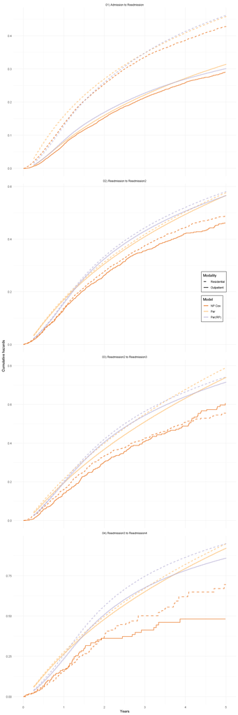

Figure 1b. Estimate of Cumulative Hazards, Five States Model, 1st Patient

```r
fig_diff_mod_ab+ theme(legend.position=c(.9,.585))
```

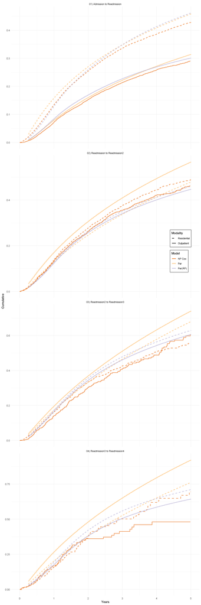

Figure 1b. Estimate of Cumulative Hazards, Five States Model, 2nd Patient (3 years arrival)

```r
fig_diff_mod_ab_1096+ theme(legend.position=c(.9,.585))
```

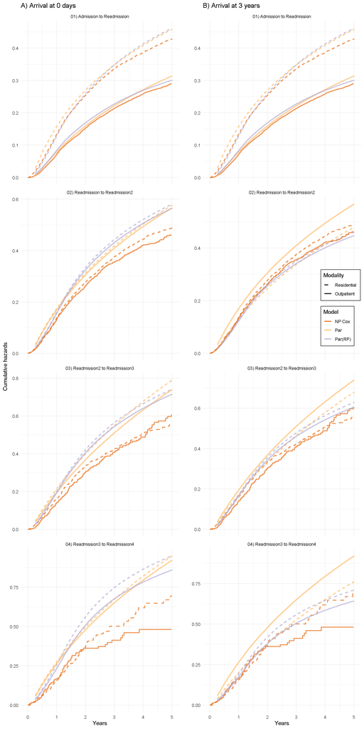

Figure 1c. Estimate of Cumulative Hazards, Five States Model, 1st & 2nd Patient

```r
ggarrange(fig_diff_mod_ab+ theme(legend.position="none")+ggtitle("A) Arrival at 0 days"),
          fig_diff_mod_ab_1096+ theme(legend.position=c(.87,.585))+ ylab("")+ggtitle("B) Arrival at 3 years"))
```

# Transition Probabilites of the Multistate Model

For mstate package, it is possible to use simulation to calculate transition probabilities through `mssample`.

In semi-Markov models, solving the Kolmogorov forward equation numerically is not feasible because the transition is no longer a deterministic function of t, depending on the transition history to estimate differences. Considering the abovementioned, we calculated the transition probabilities not through a deterministic approach, but following a probabilistic one through resamples.

The cumulative hazards obtained are used to simulate the times at which patients transition between health states, that is, state occupancy probabilities with a “clock-reset” model.

```r
time_before_transprob<-Sys.time()

for(i in c(90,365,1096,1827)){
  set.seed(1234)
  flexsurv::pmatrix.simfs(x = sel_param_fits_a,
                        t = i, #Must be a single number unlike pmatrix.fs
                        ci = T,
                        B= n_iter/10, #Increasing B is usually more expensive than increasing M. NUmber of simulations from the normal asymptotic distribution. MOre, more accuracy
                        newdat= newdat_a,
                        tvar="trans",
                        #tcovs= "arrival",# Predicatable time-dependent covariates such as age
                        cores= 6,
                        M = 1e5,#Number of individual trajectories to simulate.
                        trans = trans_matrix) %>%
  assign(paste0("pmatrix1_t_",i),.,envir=.GlobalEnv)
}

for(i in c(90,365,1096,1827)){
  set.seed(1234)
  flexsurv::pmatrix.simfs(x = sel_param_fits_b,
                        t = i,
                        ci = T,
                        B= n_iter/10,
                        newdat= newdat_b,
                        tvar="trans",
                        #tcovs= "arrival",
                        #M = 1,#Number of individual trajectories to simulate.
                        cores= 6,#N of processor cores
                        trans = trans_matrix) %>%
  assign(paste0("pmatrix1_t_rp_",i),.,envir=.GlobalEnv)
}

for(i in c(90,365,1096,1827)){
  set.seed(1234)
  flexsurv::pmatrix.simfs(x = sel_param_fits_a,
                        t = i, #Must be a single number unlike pmatrix.fs
                        ci = T,
                        B= n_iter/10, #Increasing B is usually more expensive than increasing M. NUmber of simulations from the normal asymptotic distribution. MOre, more accuracy
                        newdat= newdat_a_1096,
                        tvar="trans",
                        #tcovs= "arrival",# Predicatable time-dependent covariates such as age
                        cores= 6,
                        M = 1e5,#Number of individual trajectories to simulate.
                        trans = trans_matrix) %>%
  assign(paste0("pmatrix1_t_a_1096_",i),.,envir=.GlobalEnv)
}

for(i in c(90,365,1096,1827)){
  set.seed(1234)
  flexsurv::pmatrix.simfs(x = sel_param_fits_b,
                        t = i,
                        ci = T,
                        B= n_iter/10,
                        newdat= newdat_b_1096,
                        tvar="trans",
                        #tcovs= "arrival",
                        M = 1e5,#Number of individual trajectories to simulate.
                        cores= 6,#N of processor cores
                        trans = trans_matrix) %>%
  assign(paste0("pmatrix1_t_b_1096_",i),.,envir=.GlobalEnv)
}

time_after_transprob<-Sys.time()

paste0("Time in process: ");time_after_transprob-time_before_transprob
```

```
## [1] "Time in process: "
```

```
## Time difference of 16.94223 hours
```